# Device Failures Undersampling

Device Failures: Predict when which devices on trucks that will fail given the date of the failure and the number of attributes.

Import Packages

```python
import numpy as np
import pandas as pd
import matplotlib.pyplot as plt
```

Read in the dataset

```python
df = pd.read_csv('project4.csv')
```

Analyze the Dataset

```python
df.shape
```

```
(124494, 12)
```

```python
df.head()
```

|  | date | device | failure | attribute1 | attribute2 | attribute3 | attribute4 | attribute5 | attribute6 | attribute7 | attribute8 | attribute9 |
| --- | --- | --- | --- | --- | --- | --- | --- | --- | --- | --- | --- | --- |
| 0 | 2015-01-01 | S1F01085 | 0 | 215630672 | 56 | 0 | 52 | 6 | 407438 | 0 | 0 | 7 |
| 1 | 2015-01-01 | S1F0166B | 0 | 61370680 | 0 | 3 | 0 | 6 | 403174 | 0 | 0 | 0 |
| 2 | 2015-01-01 | S1F01E6Y | 0 | 173295968 | 0 | 0 | 0 | 12 | 237394 | 0 | 0 | 0 |
| 3 | 2015-01-01 | S1F01JE0 | 0 | 79694024 | 0 | 0 | 0 | 6 | 410186 | 0 | 0 | 0 |
| 4 | 2015-01-01 | S1F01R2B | 0 | 135970480 | 0 | 0 | 0 | 15 | 313173 | 0 | 0 | 3 |

```python
df.info()
```

```
<class 'pandas.core.frame.DataFrame'>
RangeIndex: 124494 entries, 0 to 124493
Data columns (total 12 columns):
date          124494 non-null object
device        124494 non-null object
failure       124494 non-null int64
attribute1    124494 non-null int64
attribute2    124494 non-null int64
attribute3    124494 non-null int64
attribute4    124494 non-null int64
attribute5    124494 non-null int64
attribute6    124494 non-null int64
attribute7    124494 non-null int64
attribute8    124494 non-null int64
attribute9    124494 non-null int64
dtypes: int64(10), object(2)
memory usage: 11.4+ MB
```

Create a column called 'day' which turns the date into float format so that it can be recognized by recognized by the computer. This will allow us to sort the dataframe from the oldest documentation to the most recent one

```python
df['day'] = df.date.map(lambda x: (int(x[5:7])+int(x[8:])*.01))
```

```python
df.head()
```

|  | date | device | failure | attribute1 | attribute2 | attribute3 | attribute4 | attribute5 | attribute6 | attribute7 | attribute8 | attribute9 | day |
| --- | --- | --- | --- | --- | --- | --- | --- | --- | --- | --- | --- | --- | --- |
| 0 | 2015-01-01 | S1F01085 | 0 | 215630672 | 56 | 0 | 52 | 6 | 407438 | 0 | 0 | 7 | 1.01 |
| 1 | 2015-01-01 | S1F0166B | 0 | 61370680 | 0 | 3 | 0 | 6 | 403174 | 0 | 0 | 0 | 1.01 |
| 2 | 2015-01-01 | S1F01E6Y | 0 | 173295968 | 0 | 0 | 0 | 12 | 237394 | 0 | 0 | 0 | 1.01 |
| 3 | 2015-01-01 | S1F01JE0 | 0 | 79694024 | 0 | 0 | 0 | 6 | 410186 | 0 | 0 | 0 | 1.01 |
| 4 | 2015-01-01 | S1F01R2B | 0 | 135970480 | 0 | 0 | 0 | 15 | 313173 | 0 | 0 | 3 | 1.01 |

Order the dataset by the date

```python
df.sort_values('day', inplace = True)
```

Check to see if there are any duplicated columns

```python
df.duplicated().sum()
```

```
0
```

Only keep the latest documentation for each device in order to make our data most relevant

```python
df = df.drop_duplicates('device', keep = 'last')
```

```python
df.head()
```

|  | date | device | failure | attribute1 | attribute2 | attribute3 | attribute4 | attribute5 | attribute6 | attribute7 | attribute8 | attribute9 | day |
| --- | --- | --- | --- | --- | --- | --- | --- | --- | --- | --- | --- | --- | --- |
| 3051 | 2015-01-03 | W1F0WJFT | 0 | 142903640 | 0 | 0 | 0 | 9 | 217819 | 0 | 0 | 1 | 1.03 |
| 3516 | 2015-01-04 | S1F04KSC | 0 | 243217648 | 392 | 24929 | 529 | 3 | 339302 | 0 | 0 | 10137 | 1.04 |
| 5431 | 2015-01-05 | W1F0YKBQ | 0 | 113412128 | 0 | 0 | 0 | 8 | 24 | 0 | 0 | 0 | 1.05 |
| 5502 | 2015-01-05 | W1F1ARYY | 0 | 224061208 | 0 | 0 | 0 | 8 | 267406 | 0 | 0 | 0 | 1.05 |
| 5513 | 2015-01-05 | W1F1BQNS | 0 | 52827696 | 0 | 0 | 0 | 9 | 287621 | 0 | 0 | 1 | 1.05 |

Make sure that the older documentations of a device are properly removed by seeing if the first few indicies were removed

```python
df.index
```

```
Int64Index([  3051,   3516,   5431,   5502,   5513,   5461,   5468,   5476,
              5234,   5302,
            ...
            124469, 124468, 124467, 124466, 124465, 124464, 124463, 124492,
            124477, 124493],
           dtype='int64', length=1168)
```

Check to see how many rows were dropped

```python
df.shape
```

```
(1168, 13)
```

Check to see that all the values in the 'device' column are unique

```python
df.duplicated('device').sum()
```

```
0
```

Look at the number of failures within the dataframe.

```python
df.failure[df.failure==1].shape
```

```
(101,)
```

See if the new failure of devices over total devices documented ratio is still the same with out new dataset.

```python
101/124494
```

```
0.0008112840779475316
```

Analyze the new dataset

```python
df.describe()
```

|  | failure | attribute1 | attribute2 | attribute3 | attribute4 | attribute5 | attribute6 | attribute7 | attribute8 | attribute9 | day |
| --- | --- | --- | --- | --- | --- | --- | --- | --- | --- | --- | --- |
| count | 1168.000000 | 1.168000e+03 | 1168.000000 | 1168.000000 | 1168.000000 | 1168.000000 | 1168.000000 | 1168.000000 | 1168.000000 | 1168.000000 | 1168.000000 |
| mean | 0.086473 | 1.220673e+08 | 873.006849 | 31.270548 | 9.816781 | 12.442637 | 270190.081336 | 4.446918 | 4.446918 | 49.273116 | 4.435180 |
| std | 0.281181 | 7.035912e+07 | 5993.391146 | 738.567698 | 78.979344 | 12.371227 | 104361.153976 | 43.744396 | 43.744396 | 678.406911 | 3.369271 |
| min | 0.000000 | 0.000000e+00 | 0.000000 | 0.000000 | 0.000000 | 1.000000 | 12.000000 | 0.000000 | 0.000000 | 0.000000 | 1.030000 |
| 25% | 0.000000 | 5.969821e+07 | 0.000000 | 0.000000 | 0.000000 | 7.000000 | 212482.250000 | 0.000000 | 0.000000 | 0.000000 | 1.060000 |
| 50% | 0.000000 | 1.221506e+08 | 0.000000 | 0.000000 | 0.000000 | 9.000000 | 261072.000000 | 0.000000 | 0.000000 | 0.000000 | 3.270000 |
| 75% | 0.000000 | 1.823452e+08 | 0.000000 | 0.000000 | 0.000000 | 12.000000 | 328148.250000 | 0.000000 | 0.000000 | 1.000000 | 8.140000 |
| max | 1.000000 | 2.433294e+08 | 64792.000000 | 24929.000000 | 1666.000000 | 98.000000 | 689161.000000 | 832.000000 | 832.000000 | 18701.000000 | 11.020000 |

Looking at the .describe(), attribute7 and attribute8 seem to be the same. We confirm that below.

```python
df[df.attribute7 != df.attribute8]
```

|  | date | device | failure | attribute1 | attribute2 | attribute3 | attribute4 | attribute5 | attribute6 | attribute7 | attribute8 | attribute9 | day |
| --- | --- | --- | --- | --- | --- | --- | --- | --- | --- | --- | --- | --- | --- |

As a result, we drop 'attribute 8'.

```python
df = df.drop('attribute8', axis = 1)
```

Check how correlated each attribute is to the column 'failure'.

```python
df.corr(method = 'spearman').failure
```

```
failure       1.000000
attribute1    0.019745
attribute2    0.321986
attribute3    0.016474
attribute4    0.335016
attribute5    0.089090
attribute6   -0.021981
attribute7    0.409430
attribute9    0.020216
day           0.031474
Name: failure, dtype: float64
```

Add a column for the month

```python
df['mon']=df.date.map(lambda x: x[5:7])
```

```python
df.mon = df.mon.astype(int)
```

Add a column for the year

```python
df['year']=df.date.map(lambda x: x[0:4])
```

Below, we find out that all the data is from 2015, so we drop the year column.

```python
df.year.unique()
```

```
array(['2015'], dtype=object)
```

```python
df = df.drop('year', axis = 1)
```

Creates a column for the day of the week in which the documentation occured.

```python
import datetime
```

```python
#starts at monday = 0, sunday = 6
df['day']= df.date.map(lambda x: datetime.date(int(x[0:4]),int(x[5:7]),int(x[8:])).weekday())
```

```python
df.head()
```

|  | date | device | failure | attribute1 | attribute2 | attribute3 | attribute4 | attribute5 | attribute6 | attribute7 | attribute9 | day | mon |
| --- | --- | --- | --- | --- | --- | --- | --- | --- | --- | --- | --- | --- | --- |
| 3051 | 2015-01-03 | W1F0WJFT | 0 | 142903640 | 0 | 0 | 0 | 9 | 217819 | 0 | 1 | 5 | 1 |
| 3516 | 2015-01-04 | S1F04KSC | 0 | 243217648 | 392 | 24929 | 529 | 3 | 339302 | 0 | 10137 | 6 | 1 |
| 5431 | 2015-01-05 | W1F0YKBQ | 0 | 113412128 | 0 | 0 | 0 | 8 | 24 | 0 | 0 | 0 | 1 |
| 5502 | 2015-01-05 | W1F1ARYY | 0 | 224061208 | 0 | 0 | 0 | 8 | 267406 | 0 | 0 | 0 | 1 |
| 5513 | 2015-01-05 | W1F1BQNS | 0 | 52827696 | 0 | 0 | 0 | 9 | 287621 | 0 | 1 | 0 | 1 |

Look at what unique device names there are

```python
df.device.unique()
```

```
array(['W1F0WJFT', 'S1F04KSC', 'W1F0YKBQ', ..., 'Z1F0QL3N', 'W1F0FY92',
       'Z1F0QLC1'], dtype=object)
```

Create a column for first letter of each device name

```python
df['type'] = df.device.map(lambda x: x[0:1])
```

We can see below that there are only three unique first letters of device names

```python
df.type.unique()
```

```
array(['W', 'S', 'Z'], dtype=object)
```

```python
df.head()
```

|  | date | device | failure | attribute1 | attribute2 | attribute3 | attribute4 | attribute5 | attribute6 | attribute7 | attribute9 | day | mon | type |
| --- | --- | --- | --- | --- | --- | --- | --- | --- | --- | --- | --- | --- | --- | --- |
| 3051 | 2015-01-03 | W1F0WJFT | 0 | 142903640 | 0 | 0 | 0 | 9 | 217819 | 0 | 1 | 5 | 1 | W |
| 3516 | 2015-01-04 | S1F04KSC | 0 | 243217648 | 392 | 24929 | 529 | 3 | 339302 | 0 | 10137 | 6 | 1 | S |
| 5431 | 2015-01-05 | W1F0YKBQ | 0 | 113412128 | 0 | 0 | 0 | 8 | 24 | 0 | 0 | 0 | 1 | W |
| 5502 | 2015-01-05 | W1F1ARYY | 0 | 224061208 | 0 | 0 | 0 | 8 | 267406 | 0 | 0 | 0 | 1 | W |
| 5513 | 2015-01-05 | W1F1BQNS | 0 | 52827696 | 0 | 0 | 0 | 9 | 287621 | 0 | 1 | 0 | 1 | W |

Make a seperate dataframe for failures

```python
fail = df[df.failure ==1]
```

```python
fail.head()
```

|  | date | device | failure | attribute1 | attribute2 | attribute3 | attribute4 | attribute5 | attribute6 | attribute7 | attribute9 | day | mon | type |
| --- | --- | --- | --- | --- | --- | --- | --- | --- | --- | --- | --- | --- | --- | --- |
| 4885 | 2015-01-05 | S1F0RRB1 | 1 | 48467332 | 64776 | 0 | 841 | 8 | 39267 | 56 | 1 | 0 | 1 | S |
| 6879 | 2015-01-07 | S1F0CTDN | 1 | 184069720 | 528 | 0 | 4 | 9 | 387871 | 32 | 3 | 2 | 1 | S |
| 8823 | 2015-01-09 | W1F0PNA5 | 1 | 136429411 | 64784 | 0 | 406 | 30 | 224801 | 8 | 0 | 4 | 1 | W |
| 11957 | 2015-01-13 | W1F13SRV | 1 | 188251248 | 2040 | 0 | 0 | 6 | 39345 | 32 | 1 | 1 | 1 | W |
| 12668 | 2015-01-14 | W1F1230J | 1 | 220461296 | 0 | 0 | 0 | 14 | 325125 | 0 | 0 | 2 | 1 | W |

Examine the rate of failures for each month

```python
#which month has the highest rate of traffic accidents?
mon_rate = fail.mon.value_counts()/df.mon.value_counts()
```

```python
mon_rate
```

```
1     0.060150
2     0.304348
3     0.048913
4     0.080357
5     0.250000
6     1.000000
7     0.933333
8     0.026667
9          NaN
10    0.026087
11         NaN
Name: mon, dtype: float64
```

We can see that June and July have the highest rates

```python
mon_rate = pd.DataFrame(mon_rate)
```

Check to see if there is a noticeable pattern between month and device failure rate

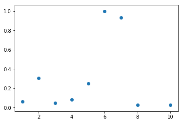

```python
plt.scatter(mon_rate.index, mon_rate.mon)
plt.show()
```

Examine the rate of failures for each day of the week.

```python
fail.day.value_counts()/df.day.value_counts()
```

```
0    0.073770
1    0.055375
2    0.076142
3    0.166667
4    0.076923
5    0.833333
6    0.750000
Name: day, dtype: float64
```

Examine the failure rate for the first letter of the device name.

```python
#what is the relationship between type of device and fail rate?
fail.type.value_counts()/df.type.value_counts()
```

```
S    0.075472
W    0.093079
Z    0.100457
Name: type, dtype: float64
```

Compare the distributions of the fail datset and our regular dataset.

```python
fail.describe()
```

|  | failure | attribute1 | attribute2 | attribute3 | attribute4 | attribute5 | attribute6 | attribute7 | attribute9 | day | mon |
| --- | --- | --- | --- | --- | --- | --- | --- | --- | --- | --- | --- |
| count | 101.0 | 1.010000e+02 | 101.000000 | 101.000000 | 101.000000 | 101.000000 | 101.000000 | 101.000000 | 101.000000 | 101.000000 | 101.000000 |
| mean | 1.0 | 1.263486e+08 | 4206.336634 | 4.009901 | 51.069307 | 15.821782 | 255938.376238 | 32.059406 | 24.217822 | 2.019802 | 3.970297 |
| std | 0.0 | 6.943191e+07 | 13079.829641 | 32.322901 | 193.200117 | 15.814168 | 105043.501480 | 119.737197 | 157.152003 | 1.696940 | 2.491808 |
| min | 1.0 | 4.527376e+06 | 0.000000 | 0.000000 | 0.000000 | 4.000000 | 24.000000 | 0.000000 | 0.000000 | 0.000000 | 1.000000 |
| 25% | 1.0 | 6.823931e+07 | 0.000000 | 0.000000 | 0.000000 | 8.000000 | 224801.000000 | 0.000000 | 0.000000 | 0.000000 | 2.000000 |
| 50% | 1.0 | 1.364294e+08 | 0.000000 | 0.000000 | 1.000000 | 10.000000 | 265506.000000 | 0.000000 | 0.000000 | 2.000000 | 4.000000 |
| 75% | 1.0 | 1.840697e+08 | 1184.000000 | 0.000000 | 18.000000 | 14.000000 | 304990.000000 | 16.000000 | 1.000000 | 3.000000 | 6.000000 |
| max | 1.0 | 2.432612e+08 | 64784.000000 | 318.000000 | 1666.000000 | 91.000000 | 574599.000000 | 832.000000 | 1165.000000 | 6.000000 | 10.000000 |

```python
df.describe()
```

|  | failure | attribute1 | attribute2 | attribute3 | attribute4 | attribute5 | attribute6 | attribute7 | attribute9 | day | mon |
| --- | --- | --- | --- | --- | --- | --- | --- | --- | --- | --- | --- |
| count | 1168.000000 | 1.168000e+03 | 1168.000000 | 1168.000000 | 1168.000000 | 1168.000000 | 1168.000000 | 1168.000000 | 1168.000000 | 1168.000000 | 1168.000000 |
| mean | 0.086473 | 1.220673e+08 | 873.006849 | 31.270548 | 9.816781 | 12.442637 | 270190.081336 | 4.446918 | 49.273116 | 1.519692 | 4.302226 |
| std | 0.281181 | 7.035912e+07 | 5993.391146 | 738.567698 | 78.979344 | 12.371227 | 104361.153976 | 43.744396 | 678.406911 | 1.426745 | 3.349444 |
| min | 0.000000 | 0.000000e+00 | 0.000000 | 0.000000 | 0.000000 | 1.000000 | 12.000000 | 0.000000 | 0.000000 | 0.000000 | 1.000000 |
| 25% | 0.000000 | 5.969821e+07 | 0.000000 | 0.000000 | 0.000000 | 7.000000 | 212482.250000 | 0.000000 | 0.000000 | 0.000000 | 1.000000 |
| 50% | 0.000000 | 1.221506e+08 | 0.000000 | 0.000000 | 0.000000 | 9.000000 | 261072.000000 | 0.000000 | 0.000000 | 1.000000 | 3.000000 |
| 75% | 0.000000 | 1.823452e+08 | 0.000000 | 0.000000 | 0.000000 | 12.000000 | 328148.250000 | 0.000000 | 1.000000 | 3.000000 | 8.000000 |
| max | 1.000000 | 2.433294e+08 | 64792.000000 | 24929.000000 | 1666.000000 | 98.000000 | 689161.000000 | 832.000000 | 18701.000000 | 6.000000 | 11.000000 |

Turn our datset into a csv file so that it can be used in Device Failures Part 2.

```python
df.to_csv('df_final.csv')
```

Create a dataframe for the devices which did not fail.

```python
no_fail = df[df.failure == 0]
```

### Undersampling

Since the number of documented failures in our dataset is very low, we will use a technique called undersampling in which we will randomly remove data which did not fail in order to create a higher fail to did not fail ratio.

```python
no_fail.head()
```

|  | date | device | failure | attribute1 | attribute2 | attribute3 | attribute4 | attribute5 | attribute6 | attribute7 | attribute9 | day | mon | type |
| --- | --- | --- | --- | --- | --- | --- | --- | --- | --- | --- | --- | --- | --- | --- |
| 3051 | 2015-01-03 | W1F0WJFT | 0 | 142903640 | 0 | 0 | 0 | 9 | 217819 | 0 | 1 | 5 | 1 | W |
| 3516 | 2015-01-04 | S1F04KSC | 0 | 243217648 | 392 | 24929 | 529 | 3 | 339302 | 0 | 10137 | 6 | 1 | S |
| 5431 | 2015-01-05 | W1F0YKBQ | 0 | 113412128 | 0 | 0 | 0 | 8 | 24 | 0 | 0 | 0 | 1 | W |
| 5502 | 2015-01-05 | W1F1ARYY | 0 | 224061208 | 0 | 0 | 0 | 8 | 267406 | 0 | 0 | 0 | 1 | W |
| 5513 | 2015-01-05 | W1F1BQNS | 0 | 52827696 | 0 | 0 | 0 | 9 | 287621 | 0 | 1 | 0 | 1 | W |

```python
no_fail.index
```

```
Int64Index([  3051,   3516,   5431,   5502,   5513,   5461,   5468,   5476,
              5234,   5302,
            ...
            124469, 124468, 124467, 124466, 124465, 124464, 124463, 124492,
            124477, 124493],
           dtype='int64', length=1067)
```

Create a new dataset, df2, for undersampling

```python
no_fail = no_fail.reset_index()
```

```python
rand = np.random.randint(0,1067,202)
```

```python
df2 = no_fail.iloc[rand,:]
```

```python
df2=fail.append(df2, ignore_index= True)
```

```python
df2.head()
```

|  | attribute1 | attribute2 | attribute3 | attribute4 | attribute5 | attribute6 | attribute7 | attribute9 | date | day | device | failure | index | mon | type |
| --- | --- | --- | --- | --- | --- | --- | --- | --- | --- | --- | --- | --- | --- | --- | --- |
| 0 | 48467332 | 64776 | 0 | 841 | 8 | 39267 | 56 | 1 | 2015-01-05 | 0 | S1F0RRB1 | 1 | NaN | 1 | S |
| 1 | 184069720 | 528 | 0 | 4 | 9 | 387871 | 32 | 3 | 2015-01-07 | 2 | S1F0CTDN | 1 | NaN | 1 | S |
| 2 | 136429411 | 64784 | 0 | 406 | 30 | 224801 | 8 | 0 | 2015-01-09 | 4 | W1F0PNA5 | 1 | NaN | 1 | W |
| 3 | 188251248 | 2040 | 0 | 0 | 6 | 39345 | 32 | 1 | 2015-01-13 | 1 | W1F13SRV | 1 | NaN | 1 | W |
| 4 | 220461296 | 0 | 0 | 0 | 14 | 325125 | 0 | 0 | 2015-01-14 | 2 | W1F1230J | 1 | NaN | 1 | W |

```python
df2 = df2.drop('index', axis = 1)
```

```python
df2.iloc[104:110,:]
```

|  | attribute1 | attribute2 | attribute3 | attribute4 | attribute5 | attribute6 | attribute7 | attribute9 | date | day | device | failure | mon | type |
| --- | --- | --- | --- | --- | --- | --- | --- | --- | --- | --- | --- | --- | --- | --- |
| 104 | 148434224 | 0 | 0 | 0 | 7 | 388782 | 0 | 0 | 2015-01-07 | 2 | S1F0R4JY | 0 | 1 | S |
| 105 | 54054848 | 0 | 0 | 0 | 12 | 360054 | 0 | 0 | 2015-11-02 | 0 | W1F0FEH7 | 0 | 11 | W |
| 106 | 231060952 | 0 | 0 | 0 | 8 | 324186 | 0 | 2 | 2015-08-14 | 4 | Z1F0LM11 | 0 | 8 | Z |
| 107 | 27764680 | 0 | 0 | 0 | 8 | 331760 | 0 | 7 | 2015-08-14 | 4 | S1F0LBMG | 0 | 8 | S |
| 108 | 7333128 | 0 | 0 | 0 | 5 | 206114 | 0 | 5 | 2015-01-05 | 0 | S1F0LEBM | 0 | 1 | S |
| 109 | 11590952 | 0 | 0 | 0 | 9 | 258771 | 0 | 0 | 2015-10-19 | 0 | S1F130JB | 0 | 10 | S |

Create our dataset, X, for our independent variables.

```python
X = df2.drop(['device', 'failure', 'date'], axis = 1)
```

```python
X=pd.get_dummies(X, drop_first = True)
```

```python
X.head()
```

|  | attribute1 | attribute2 | attribute3 | attribute4 | attribute5 | attribute6 | attribute7 | attribute9 | day | mon | type_W | type_Z |
| --- | --- | --- | --- | --- | --- | --- | --- | --- | --- | --- | --- | --- |
| 0 | 48467332 | 64776 | 0 | 841 | 8 | 39267 | 56 | 1 | 0 | 1 | 0 | 0 |
| 1 | 184069720 | 528 | 0 | 4 | 9 | 387871 | 32 | 3 | 2 | 1 | 0 | 0 |
| 2 | 136429411 | 64784 | 0 | 406 | 30 | 224801 | 8 | 0 | 4 | 1 | 1 | 0 |
| 3 | 188251248 | 2040 | 0 | 0 | 6 | 39345 | 32 | 1 | 1 | 1 | 1 | 0 |
| 4 | 220461296 | 0 | 0 | 0 | 14 | 325125 | 0 | 0 | 2 | 1 | 1 | 0 |

Create a function, explosion_s, which will determine if any of the columns in X have a high correlation with failure when added, subtracted, multiplied, or divided.

```python
#df is numerical only
#takes much longer
def explosion_s(df, y_col, cutoff, add_bool, sub_bool, mult_bool, div_bool):
    num_col = df.shape[1]
    def factorial_add(n):
            if n ==0:
                return(0)
            else:
                return(n)+ factorial_add(n-1)
    num_col2= factorial_add(num_col - 1)
    if add_bool == True:
        add = pd.DataFrame()
        for i in range(num_col):
            for j in range(i+1,num_col):
                add[df.columns[i]+ " + " + df.columns[j]] = (df.iloc[:,i]+df.iloc[:,j])
        add['y']=y_col
        addpear = {}
        for i in range(num_col2):
            if(add.corr(method = 'spearman').iloc[i,num_col2]>cutoff):
                print('add')
                print(add.corr(method = 'spearman').columns[i])
                addpear[add.corr(method = 'spearman').columns[i]] = add.corr(method = 'spearman').iloc[i,num_col2]
        print(addpear)
    else:
        addpear = {}
    if sub_bool == True:
        sub = pd.DataFrame()
        for i in range(num_col):
            for j in range(i+1,num_col):
                sub[df.columns[i]+ " - " + df.columns[j]] = (df.iloc[:,i]-df.iloc[:,j])
        sub['y']=y_col
        subpear = {}
        for i in range(num_col2):
            if(sub.corr(method = 'spearman').iloc[i,num_col2]>cutoff):
                print('sub')
                print(sub.corr(method = 'spearman').columns[i])
                subpear[sub.corr(method = 'spearman').columns[i]] = sub.corr(method = 'spearman').iloc[i,num_col2]
        print(subpear)
    else:
        subpear = {}
    if div_bool == True:
        div = pd.DataFrame()
        for i in range(num_col):
            for j in range(i+1,num_col):
                div[df.columns[i]+ " / " + df.columns[j]] = ((df.iloc[:,i]+1)/(df.iloc[:,j]+1))
        div['y']=y_col
        divpear = {}
        for i in range(num_col2):
            if(div.corr(method = 'spearman').iloc[i,num_col2]>cutoff):
                print('div')
                print(div.corr(method = 'spearman').columns[i])
                divpear[div.corr(method = 'spearman').columns[i]] = div.corr(method = 'spearman').iloc[i,num_col2]
        print(divpear)
    else:
        divpear = {}
    if mult_bool == True:
        mult = pd.DataFrame()
        for i in range(num_col):
            for j in range(i+1,num_col):
                mult[df.columns[i]+ " * " + df.columns[j]] = (df.iloc[:,i]*df.iloc[:,j])
        mult['y']=y_col
        multpear = {}
        for i in range(num_col2):
            if(mult.corr(method = 'spearman').iloc[i,num_col2]>cutoff):
                print('mult')
                print(mult.corr(method = 'spearman').columns[i])
                multpear[mult.corr(method = 'spearman').columns[i]] = mult.corr(method = 'spearman').iloc[i,num_col2]
        print(multpear)
    else:
        multpear = {}
```

Create a dataset, y, for our dependent variable, failure.

```python
y = df2.failure
```

Feed X and y into explosion_s.

```python
explosion_s(X, y, .5, True, True, True, True)
```

```
add
attribute2 + attribute4
add
attribute2 + attribute7
add
attribute3 + attribute4
add
attribute4 + attribute7
add
attribute4 + attribute9
{'attribute2 + attribute4': 0.6335797062603724, 'attribute2 + attribute7': 0.6735114233731113, 'attribute3 + attribute4': 0.5193779720298372, 'attribute4 + attribute7': 0.645759246987141, 'attribute4 + attribute9': 0.5143611131139401}
{}
{}
mult
attribute1 * attribute2
mult
attribute1 * attribute4
mult
attribute1 * attribute7
mult
attribute2 * attribute5
mult
attribute2 * attribute6
mult
attribute2 * day
mult
attribute2 * mon
mult
attribute4 * attribute5
mult
attribute4 * attribute6
mult
attribute4 * day
mult
attribute4 * mon
mult
attribute5 * attribute7
mult
attribute6 * attribute7
mult
attribute7 * day
mult
attribute7 * mon
{'attribute1 * attribute2': 0.5174202503835206, 'attribute1 * attribute4': 0.5411689320736941, 'attribute1 * attribute7': 0.5272403742404916, 'attribute2 * attribute5': 0.52037579670103, 'attribute2 * attribute6': 0.5232216621183051, 'attribute2 * day': 0.5189526987662939, 'attribute2 * mon': 0.5170…
```

See if the correlation of attribute2 + attribute4 + attribute7 with failure is high.

```python
(X['attribute2']+X['attribute4']+X['attribute7']).corr(y, method = 'spearman')
```

```
0.6903802825628522
```

Add the features that had above a .59 correlation to X.

```python
df_test = X

df_test['2+4'] = df_test.attribute2+df_test.attribute4
df_test['2+7'] = df_test.attribute2+df_test.attribute7
df_test['4+7'] = df_test.attribute4+df_test.attribute7
df_test['2+4+7'] = df_test.attribute2+df_test.attribute4+df_test.attribute7
df_test['4*6'] = df_test.attribute4*df_test.attribute6
df_test['4*mon'] = df_test.attribute4*df_test.mon
df_test['2/9'] = df_test.attribute2/df_test.attribute9
df_test['4/5'] = df_test.attribute4/df_test.attribute5
df_test['4/6'] = df_test.attribute4/df_test.attribute6
df_test['4/9'] = df_test.attribute4/df_test.attribute9
df_test['4/day'] = df_test.attribute4/df_test.day
df_test['4/type_W'] = df_test.attribute4/df_test.type_W
```

```python
df_test.head()
```

|  | attribute1 | attribute2 | attribute3 | attribute4 | attribute5 | attribute6 | attribute7 | attribute9 | day | mon | ... | 4+7 | 2+4+7 | 4*6 | 4*mon | 2/9 | 4/5 | 4/6 | 4/9 | 4/day | 4/type_W |
| --- | --- | --- | --- | --- | --- | --- | --- | --- | --- | --- | --- | --- | --- | --- | --- | --- | --- | --- | --- | --- | --- |
| 0 | 48467332 | 64776 | 0 | 841 | 8 | 39267 | 56 | 1 | 0 | 1 | ... | 897 | 65673 | 33023547 | 841 | 6.477600e+04 | 105.125000 | 0.021417 | 841.000000 | inf | inf |
| 1 | 184069720 | 528 | 0 | 4 | 9 | 387871 | 32 | 3 | 2 | 1 | ... | 36 | 564 | 1551484 | 4 | 1.760000e+02 | 0.444444 | 0.000010 | 1.333333 | 2.000000 | inf |
| 2 | 136429411 | 64784 | 0 | 406 | 30 | 224801 | 8 | 0 | 4 | 1 | ... | 414 | 65198 | 91269206 | 406 | inf | 13.533333 | 0.001806 | inf | 101.500000 | 406.000000 |
| 3 | 188251248 | 2040 | 0 | 0 | 6 | 39345 | 32 | 1 | 1 | 1 | ... | 32 | 2072 | 0 | 0 | 2.040000e+03 | 0.000000 | 0.000000 | 0.000000 | 0.000000 | 0.000000 |
| 4 | 220461296 | 0 | 0 | 0 | 14 | 325125 | 0 | 0 | 2 | 1 | ... | 0 | 0 | 0 | 0 | NaN | 0.000000 | 0.000000 | NaN | 0.000000 | 0.000000 |

5 rows × 24 columns

```python
df_test['2/9'].fillna(-1, inplace = True)
df_test['4/5'].fillna(-1, inplace = True)
df_test['4/6'].fillna(-1, inplace = True)
df_test['4/9'].fillna(-1, inplace = True)
df_test['4/day'].fillna(-1, inplace = True)
df_test['4/type_W'].fillna(-1, inplace = True)
```

```python
df_test['2/9']=df_test['2/9'][df_test['2/9']==float('inf')]=999999
df_test['4/5']=df_test['4/5'][df_test['4/5']==float('inf')]=999999
df_test['4/6']=df_test['4/6'][df_test['4/6']==float('inf')]=999999
df_test['4/9']=df_test['4/9'][df_test['4/9']==float('inf')]=999999
df_test['4/day']=df_test['4/day'][df_test['4/day']==float('inf')]=999999
df_test['4/type_W']=df_test['4/type_W'][df_test['4/type_W']==float('inf')]=999999
```

```python
df_test = X
```

Note: We will be using tree algorithms to for our model, so having an excess of features will not affect the quality of our model.

```python
X.info()
```

```
<class 'pandas.core.frame.DataFrame'>
RangeIndex: 303 entries, 0 to 302
Data columns (total 24 columns):
attribute1    303 non-null int64
attribute2    303 non-null int64
attribute3    303 non-null int64
attribute4    303 non-null int64
attribute5    303 non-null int64
attribute6    303 non-null int64
attribute7    303 non-null int64
attribute9    303 non-null int64
day           303 non-null int64
mon           303 non-null int32
type_W        303 non-null uint8
type_Z        303 non-null uint8
2+4           303 non-null int64
2+7           303 non-null int64
4+7           303 non-null int64
2+4+7         303 non-null int64
4*6           303 non-null int64
4*mon         303 non-null int64
2/9           303 non-null int64
4/5           303 non-null int64
4/6           303 non-null int64
4/9           303 non-null int64
4/day         303 non-null int64
4/type_W      303 non-null int64
dtypes: int32(1), int64(21), uint8(2)
memory usage: 51.6 KB
```

Split X and y into training and testing sets.

```python
#use stratefy
from sklearn.model_selection import train_test_split
X_train, X_test, y_train, y_test = train_test_split(X,y,train_size = 0.8, random_state = 0)

from sklearn.model_selection import cross_val_score
```

Use cross vallidation to see which number of estimators is optimal for the random forest classifier.

```python
from sklearn.ensemble import RandomForestClassifier

rfc_range = list(range(1, 300,15))
rfc_scores = []
for est in rfc_range:
    rfc = RandomForestClassifier(n_estimators = est)
    accuracy = cross_val_score(rfc, X, y, cv=5, scoring='accuracy')
    tup = (est,accuracy.mean())
    rfc_scores.append(tup)
print(rfc_scores)
```

```
[(1, 0.7649568129737352), (16, 0.8248475233562489), (31, 0.8347399964745286), (46, 0.8213520183324519), (61, 0.8180733298078617), (76, 0.8278582760444209), (91, 0.8280186849991186), (106, 0.8180733298078617), (121, 0.8181808566895821), (136, 0.8310840824960337), (151, 0.8311916093777544), (166, 0.81…
```

```python
rfc_num = []
rfc_accuracy = []
for score in rfc_scores:
    rfc_num.append(score[0])
    rfc_accuracy.append(score[1])
```

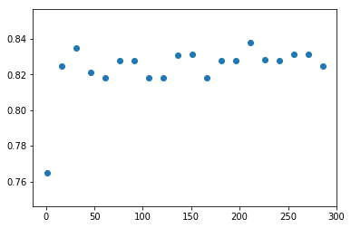

```python
plt.scatter(rfc_num,rfc_accuracy)
plt.show()
```

```python
from sklearn.ensemble import RandomForestClassifier

rfc_range = list(range(196, 226))
rfc_scores = []
for est in rfc_range:
    rfc = RandomForestClassifier(n_estimators = est)
    accuracy = cross_val_score(rfc, X, y, cv=5, scoring='accuracy')
    tup = (est,accuracy.mean())
    rfc_scores.append(tup)
print(rfc_scores)
```

```
[(196, 0.8278582760444209), (197, 0.83764322228098), (198, 0.8344174158293672), (199, 0.8345249427110876), (200, 0.8280733298078617), (201, 0.834417415829367), (202, 0.8279129208531641), (203, 0.83764322228098), (204, 0.8212991362594746), (205, 0.831136964569011), (206, 0.8311916093777543), (207, 0.…
```

```python
rfc_num = []
rfc_accuracy = []
for score in rfc_scores:
    rfc_num.append(score[0])
    rfc_accuracy.append(score[1])
```

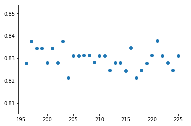

```python
plt.scatter(rfc_num,rfc_accuracy)
plt.show()
```

Use cross validation to see which number of estimators is optimal for the gradient boosting classifier.

```python
from sklearn.ensemble import GradientBoostingClassifier

gbc_range = list(range(1, 300,15))
gbc_scores = []
for est in gbc_range:
    gbc = GradientBoostingClassifier(n_estimators= est,learning_rate=.1)
    accuracy= cross_val_score(gbc, X, y, cv=5, scoring='accuracy')
    tup = (est,accuracy.mean())
    gbc_scores.append(tup)
print(gbc_scores)
```

```
[(1, 0.6666842940243256), (16, 0.8187167283624184), (31, 0.8252758681473648), (46, 0.8219971796227746), (61, 0.8219425348140315), (76, 0.8186638462894411), (91, 0.8219971796227744), (106, 0.8252229860743874), (121, 0.8219971796227744), (136, 0.8219971796227744), (151, 0.8252229860743874), (166, 0.82…
```

```python
gbc_num = []
gbc_accuracy = []
for score in gbc_scores:
    gbc_num.append(score[0])
    gbc_accuracy.append(score[1])
```

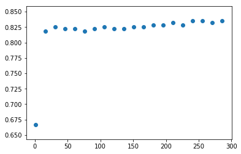

```python
plt.scatter(gbc_num,gbc_accuracy)
plt.show()
```

```python
from sklearn.ensemble import GradientBoostingClassifier

gbc_range = list(range(241,256))
gbc_scores = []
for est in gbc_range:
    gbc = GradientBoostingClassifier(n_estimators= est,learning_rate=.1)
    accuracy= cross_val_score(gbc, X, y, cv=5, scoring='accuracy')
    tup = (est,accuracy.mean())
    gbc_scores.append(tup)
print(gbc_scores)
```

```
[(241, 0.8351154591926668), (242, 0.83834126564428), (243, 0.8350625771196899), (244, 0.8351154591926668), (245, 0.83834126564428), (246, 0.8318367706680767), (247, 0.8318367706680767), (248, 0.8350625771196899), (249, 0.8351154591926668), (250, 0.8351154591926668), (251, 0.8350625771196899), (252, …
```

```python
gbc_num = []
gbc_accuracy = []
for score in gbc_scores:
    gbc_num.append(score[0])
    gbc_accuracy.append(score[1])
```

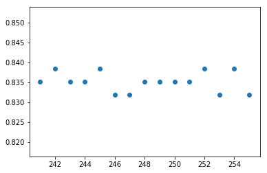

```python
#random forest estimators already picked, now seeing which GBC classifier to use  #242
plt.scatter(gbc_num,gbc_accuracy)
plt.show()
```

Train our models with the 'optimal' number of estimators and review the accuracy, f1, recall, and precision scores of each model.

```python
rfc = RandomForestClassifier(n_estimators = 220)
rfc=rfc.fit(X_train,y_train)

gbc = GradientBoostingClassifier(n_estimators=242,learning_rate=.1)
model_gbc = gbc.fit(X_train,y_train)

rfc_pred = rfc.predict(X_test)
fbc_pred = model_gbc.predict(X_test)

pred_list = [rfc_pred,fbc_pred]
from sklearn.metrics import accuracy_score, f1_score, recall_score, precision_score

for i in range(2):
    print(i)
    print(accuracy_score(y_test,pred_list[i]))
    print(f1_score(y_test,pred_list[i]))
    print(recall_score(y_test,pred_list[i]))
    print(precision_score(y_test,pred_list[i]))
```

```
0
0.8524590163934426
0.7567567567567567
0.7368421052631579
0.7777777777777778
1
0.8852459016393442
0.7999999999999999
0.7368421052631579
0.875
```

Test our model on the entire dataset to see how well it works.

```python
df_test = df.drop(['failure', 'date', 'device'], axis = 1)
df_test = pd.get_dummies(df_test, drop_first = True)

df_test.head()
```

|  | attribute1 | attribute2 | attribute3 | attribute4 | attribute5 | attribute6 | attribute7 | attribute9 | day | mon | type_W | type_Z |
| --- | --- | --- | --- | --- | --- | --- | --- | --- | --- | --- | --- | --- |
| 3051 | 142903640 | 0 | 0 | 0 | 9 | 217819 | 0 | 1 | 5 | 1 | 1 | 0 |
| 3516 | 243217648 | 392 | 24929 | 529 | 3 | 339302 | 0 | 10137 | 6 | 1 | 0 | 0 |
| 5431 | 113412128 | 0 | 0 | 0 | 8 | 24 | 0 | 0 | 0 | 1 | 1 | 0 |
| 5502 | 224061208 | 0 | 0 | 0 | 8 | 267406 | 0 | 0 | 0 | 1 | 1 | 0 |
| 5513 | 52827696 | 0 | 0 | 0 | 9 | 287621 | 0 | 1 | 0 | 1 | 1 | 0 |

```python
df_test['2+4'] = df_test.attribute2+df_test.attribute4
df_test['2+7'] = df_test.attribute2+df_test.attribute7
df_test['4+7'] = df_test.attribute4+df_test.attribute7
df_test['2+4+7'] = df_test.attribute2+df_test.attribute4+df_test.attribute7
df_test['4*6'] = df_test.attribute4*df_test.attribute6
df_test['4*mon'] = df_test.attribute4*df_test.mon
df_test['2/9'] = df_test.attribute2/df_test.attribute9
df_test['4/5'] = df_test.attribute4/df_test.attribute5
df_test['4/6'] = df_test.attribute4/df_test.attribute6
df_test['4/9'] = df_test.attribute4/df_test.attribute9
df_test['4/day'] = df_test.attribute4/df_test.day
df_test['4/type_W'] = df_test.attribute4/df_test.type_W

df_test['2/9'].fillna(-1, inplace = True)
df_test['4/5'].fillna(-1, inplace = True)
df_test['4/6'].fillna(-1, inplace = True)
df_test['4/9'].fillna(-1, inplace = True)
df_test['4/day'].fillna(-1, inplace = True)
df_test['4/type_W'].fillna(-1, inplace = True)

df_test['2/9']=df_test['2/9'][df_test['2/9']==float('inf')]=999999
df_test['4/5']=df_test['4/5'][df_test['4/5']==float('inf')]=999999
df_test['4/6']=df_test['4/6'][df_test['4/6']==float('inf')]=999999
df_test['4/9']=df_test['4/9'][df_test['4/9']==float('inf')]=999999
df_test['4/day']=df_test['4/day'][df_test['4/day']==float('inf')]=999999
df_test['4/type_W']=df_test['4/type_W'][df_test['4/type_W']==float('inf')]=999999

X2 = df_test
y2= df.failure
```

Note: When we test our model on the entire dataset, we are only concerned with the recall and precision scores since the actual dataset has such few documented failures.

```python
gbc_pred = model_gbc.predict(X2)
rfc_pred = rfc.predict(X2)
pred_list = [gbc_pred, rfc_pred]

for i in range(2):
    print(i)
    print(recall_score(y2,pred_list[i]))
    print(precision_score(y2,pred_list[i]))
```

```
0
0.9504950495049505
0.6193548387096774
1
0.9504950495049505
0.5393258426966292
```

See which features were most important in our model.

```python
importance = pd.DataFrame(model_gbc.feature_importances_)
```

```python
importance['features']= X2.columns
```

```python
importance.sort_values(0, ascending = False)
```

|  | 0 | features |
| --- | --- | --- |
| 5 | 0.243638 | attribute6 |
| 9 | 0.166563 | mon |
| 0 | 0.154927 | attribute1 |
| 8 | 0.089505 | day |
| 15 | 0.077023 | 2+4+7 |
| 4 | 0.065175 | attribute5 |
| 14 | 0.033489 | 4+7 |
| 2 | 0.028396 | attribute3 |
| 17 | 0.027275 | 4*mon |
| 6 | 0.027046 | attribute7 |
| 13 | 0.020012 | 2+7 |
| 12 | 0.018808 | 2+4 |
| 1 | 0.015884 | attribute2 |
| 3 | 0.010068 | attribute4 |
| 16 | 0.008583 | 4*6 |
| 7 | 0.008169 | attribute9 |
| 11 | 0.004026 | type_Z |
| 10 | 0.001413 | type_W |
| 18 | 0.000000 | 2/9 |
| 19 | 0.000000 | 4/5 |
| 20 | 0.000000 | 4/6 |
| 21 | 0.000000 | 4/9 |
| 22 | 0.000000 | 4/day |
| 23 | 0.000000 | 4/type_W |